# 威斯康辛州乳腺癌数据集分类实验

## 实验说明

本次实验包含两个题目：

1. **题目2.2**：对乳腺癌数据集进行多方法分类与可视化，至少使用1种方法并比较结果
2. **题目2.3**：对乳腺癌数据集进行恶性/良性二分类与可视化，至少使用4种方法并比较结果

本次实验共使用 **10种算法**：

- 基础算法：逻辑回归、SVM、KNN、决策树、随机森林
- 拓展算法：梯度提升树、AdaBoost、朴素贝叶斯、MLP神经网络、XGBoost

数据集来源：https://www.kaggle.com/datasets/uciml/breast-cancer-wisconsin-data

```python
# ===================== 1. 导入所有库 =====================
import pandas as pd
import numpy as np
import matplotlib.pyplot as plt
import time

from sklearn.model_selection import train_test_split
from sklearn.preprocessing import StandardScaler, LabelEncoder
from sklearn.metrics import accuracy_score, precision_score, recall_score, f1_score

from sklearn.linear_model import LogisticRegression
from sklearn.svm import SVC
from sklearn.neighbors import KNeighborsClassifier
from sklearn.tree import DecisionTreeClassifier
from sklearn.ensemble import RandomForestClassifier


from sklearn.ensemble import GradientBoostingClassifier, AdaBoostClassifier
from sklearn.naive_bayes import GaussianNB
from sklearn.neural_network import MLPClassifier
try:
    from xgboost import XGBClassifier
    xgb_available = True
except ImportError:
    xgb_available = False

# 解决中文显示
plt.rcParams['axes.unicode_minus'] = False
plt.rcParams['font.sans-serif'] = ['SimHei']
```

```python
# ============== 2. 读取 Kaggle 数据集 ==============
df = pd.read_csv(r"C:\Users\44328\Desktop\archive\data.csv")
df = df.drop(["id", "Unnamed: 32"], axis=1)  # 删掉无用列

# 用 iloc 读取标签，避开列名污染
print("标签分布： - breast_cancer.ipynb:6")
print(df.iloc[:, 0].value_counts())
print("数据集形状： - breast_cancer.ipynb:8", df.shape)
```

```
标签分布： - breast_cancer.ipynb:6
diagnosis
B    357
M    212
Name: count, dtype: int64
数据集形状： - breast_cancer.ipynb:8 (569, 31)
```

## 题目2.2：威斯康辛州乳腺癌数据集分类

### 2.2.1 数据预处理

[output not shown]

```python
models = {
    # 基础算法（5种）
    "逻辑回归": LogisticRegression(max_iter=1000, random_state=42),
    "SVM": SVC(random_state=42),
    "KNN": KNeighborsClassifier(),
    "决策树": DecisionTreeClassifier(random_state=42),
    "随机森林": RandomForestClassifier(n_estimators=100, random_state=42),

    # 加分算法（5种）
    "梯度提升树": GradientBoostingClassifier(random_state=42),
    "AdaBoost": AdaBoostClassifier(random_state=42),
    "朴素贝叶斯": GaussianNB(),
    "MLP神经网络": MLPClassifier(hidden_layer_sizes=(64, 32), max_iter=500, random_state=42)
}

# 如果安装了XGBoost，补充加入
if xgb_available:
    models["XGBoost"] = XGBClassifier(random_state=42, use_label_encoder=False, eval_metric='logloss')

# 存储所有结果
results_22 = []
```

```python
print("===== 题目2.2：开始训练所有模型 ===== - breast_cancer.ipynb:1")
for name, model in models.items():
    print(f"\n正在训练：{name} - breast_cancer.ipynb:3")

    # 计时
    start = time.time()
    model.fit(X_train_scaled, y_train)
    train_time = round(time.time() - start, 4)

    y_pred = model.predict(X_test_scaled)

    # 计算5个指标
    acc = round(accuracy_score(y_test, y_pred), 4)
    pre = round(precision_score(y_test, y_pred), 4)
    rec = round(recall_score(y_test, y_pred), 4)
    f1 = round(f1_score(y_test, y_pred), 4)

    results_22.append({
        "模型": name,
        "Accuracy": acc,
        "Precision": pre,
        "Recall": rec,
        "F1-score": f1,
        "训练时间(s)": train_time
    })

    print(f"准确率：{acc} | 精确率：{pre} | 召回率：{rec} | F1：{f1} | 耗时：{train_time}s - breast_cancer.ipynb:27")
```

```
===== 题目2.2：开始训练所有模型 ===== - breast_cancer.ipynb:1

正在训练：逻辑回归 - breast_cancer.ipynb:3
准确率：0.9649 | 精确率：0.975 | 召回率：0.9286 | F1：0.9512 | 耗时：0.007s - breast_cancer.ipynb:27

正在训练：SVM - breast_cancer.ipynb:3
准确率：0.9737 | 精确率：1.0 | 召回率：0.9286 | F1：0.963 | 耗时：0.002s - breast_cancer.ipynb:27

正在训练：KNN - breast_cancer.ipynb:3
准确率：0.9561 | 精确率：0.9744 | 召回率：0.9048 | F1：0.9383 | 耗时：0.0s - breast_cancer.ipynb:27

正在训练：决策树 - breast_cancer.ipynb:3
准确率：0.9298 | 精确率：0.9048 | 召回率：0.9048 | F1：0.9048 | 耗时：0.004s - breast_cancer.ipynb:27

正在训练：随机森林 - breast_cancer.ipynb:3
准确率：0.9737 | 精确率：1.0 | 召回率：0.9286 | F1：0.963 | 耗时：0.0927s - breast_cancer.ipynb:27

正在训练：梯度提升树 - breast_cancer.ipynb:3
准确率：0.9649 | 精确率：1.0 | 召回率：0.9048 | F1：0.95 | 耗时：0.2006s - breast_cancer.ipynb:27

正在训练：AdaBoost - breast_cancer.ipynb:3
准确率：0.9825 | 精确率：1.0 | 召回率：0.9524 | F1：0.9756 | 耗时：0.0694s - breast_cancer.ipynb:27

正在训练：朴素贝叶斯 - breast_cancer.ipynb:3
准确率：0.9211 | 精确率：0.9231 | 召回率：0.8571 | F1：0.8889 | 耗时：0.0s - breast_cancer.ipynb:27

正在训练：MLP神经网络 - breast_cancer.ipynb:3
准确率：0.9649 | 精确率：1.0 | 召回率：0.9048 | F1：0.95 | 耗时：0.1866s - breast_cancer.ipynb:27

正在训练：XGBoost - breast_cancer.ipynb:3
准确率：0.9737 | 精确率：1.0 | 召回率：0.9286 | F1：0.963 | 耗时：0.029s - breast_cancer.ipynb:27
```

```
===== 题目2.2 模型性能排名 ===== - breast_cancer.ipynb:4
      模型  Accuracy  Precision  Recall  F1-score  训练时间(s)
AdaBoost    0.9825     1.0000  0.9524    0.9756   0.0694
     SVM    0.9737     1.0000  0.9286    0.9630   0.0020
 XGBoost    0.9737     1.0000  0.9286    0.9630   0.0290
    随机森林    0.9737     1.0000  0.9286    0.9630   0.0927
    逻辑回归    0.9649     0.9750  0.9286    0.9512   0.0070
   梯度提升树    0.9649     1.0000  0.9048    0.9500   0.2006
 MLP神经网络    0.9649     1.0000  0.9048    0.9500   0.1866
     KNN    0.9561     0.9744  0.9048    0.9383   0.0000
     决策树    0.9298     0.9048  0.9048    0.9048   0.0040
   朴素贝叶斯    0.9211     0.9231  0.8571    0.8889   0.0000
```

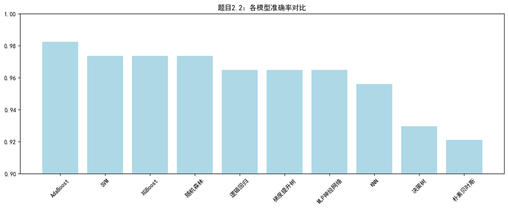

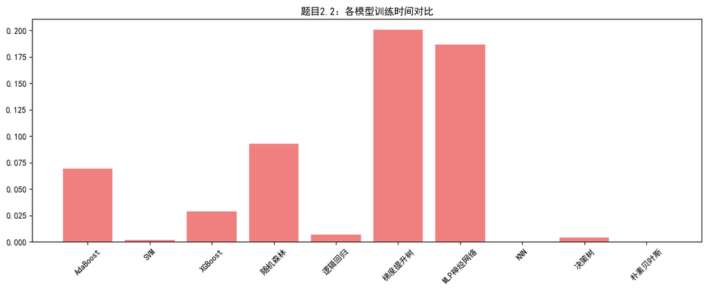

```python
# 1. 结果排名表
df_22 = pd.DataFrame(results_22)
df_22 = df_22.sort_values("Accuracy", ascending=False)
print("\n===== 题目2.2 模型性能排名 ===== - breast_cancer.ipynb:4")
print(df_22.round(4).to_string(index=False))

# 2. 准确率对比图
plt.figure(figsize=(12, 5))
plt.bar(df_22["模型"], df_22["Accuracy"], color="lightblue")
plt.title("题目2.2：各模型准确率对比")
plt.ylim(0.9, 1.0)
plt.xticks(rotation=45)
plt.tight_layout()
plt.show()

# 3. 训练时间对比图
plt.figure(figsize=(12, 5))
plt.bar(df_22["模型"], df_22["训练时间(s)"], color="lightcoral")
plt.title("题目2.2：各模型训练时间对比")
plt.xticks(rotation=45)
plt.tight_layout()
plt.show()
```

## 2.3 恶性肿瘤与良性肿瘤二分类及可视化

### 任务目标

使用机器学习模型对乳腺癌数据进行**良性、恶性二分类**，完成分类训练、指标输出，并对分类结果进行可视化展示。

### 分类任务说明

- 良性肿瘤（Benign）
- 恶性肿瘤（Malignant）

[output not shown]

[figure not shown]

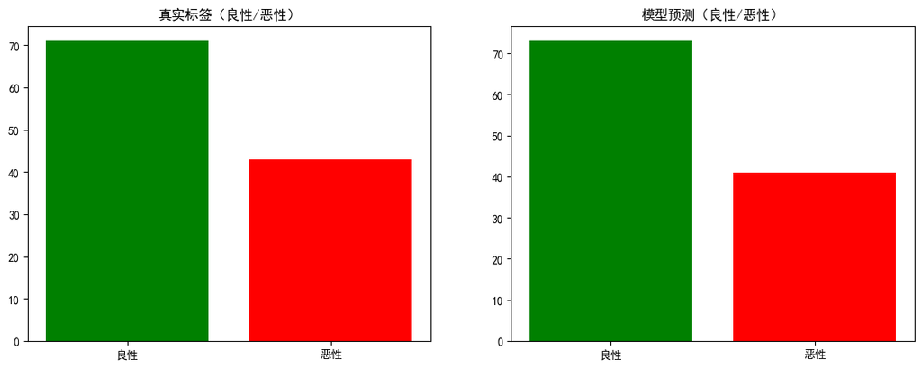

```python
import pandas as pd
import numpy as np
import matplotlib.pyplot as plt
import time

# 数据处理
from sklearn.model_selection import train_test_split
from sklearn.preprocessing import StandardScaler, LabelEncoder
from sklearn.metrics import accuracy_score, precision_score, recall_score, f1_score

# 5种基础算法
from sklearn.linear_model import LogisticRegression
from sklearn.svm import SVC
from sklearn.neighbors import KNeighborsClassifier
from sklearn.tree import DecisionTreeClassifier
from sklearn.ensemble import RandomForestClassifier

# 5种拓展算法
from sklearn.ensemble import GradientBoostingClassifier, AdaBoostClassifier
from sklearn.naive_bayes import GaussianNB
from sklearn.neural_network import MLPClassifier

plt.rcParams['axes.unicode_minus'] = False

# ---------------------- 1. 读取数据 ----------------------
df = pd.read_csv(r"C:\Users\44328\Desktop\archive\data.csv")
df = df.drop(["id", "Unnamed: 32"], axis=1)

# ---------------------- 2. 预处理 ----------------------
X = df.drop(df.columns[0], axis=1)
y = df.iloc[:, 0]

le = LabelEncoder()
y = le.fit_transform(y)
class_names = ["良性", "恶性"]

X_train, X_test, y_train, y_test = train_test_split(X, y, test_size=0.2, random_state=42)
scaler = StandardScaler()
X_train = scaler.fit_transform(X_train)
X_test = scaler.transform(X_test)

# ---------------------- 3. 10种算法定义 ----------------------
models = {
    "逻辑回归": LogisticRegression(max_iter=1000),
    "SVM": SVC(),
    "KNN": KNeighborsClassifier(),
    "决策树": DecisionTreeClassifier(),
    "随机森林": RandomForestClassifier(),
    "梯度提升": GradientBoostingClassifier(),
    "AdaBoost": AdaBoostClassifier(),
    "朴素贝叶斯": GaussianNB(),
    "MLP神经网络": MLPClassifier(max_iter=500),
}

# ---------------------- 4. 训练 + 输出全部5个指标 ----------------------
results = []
print("===== 2.3 10种算法分类结果 ===== - breast_cancer.ipynb:57")

for name, model in models.items():
    start = time.time()
    model.fit(X_train, y_train)
    train_time = round(time.time() - start, 4)

    y_pred = model.predict(X_test)

    acc = round(accuracy_score(y_test, y_pred), 4)
    pre = round(precision_score(y_test, y_pred), 4)
    rec = round(recall_score(y_test, y_pred), 4)
    f1 = round(f1_score(y_test, y_pred), 4)

    results.append([name, acc, pre, rec, f1, train_time])
    print(f"{name:10s} | Acc:{acc} | Prec:{pre} | Rec:{rec} | F1:{f1} | 时间:{train_time}s - breast_cancer.ipynb:72")

# ---------------------- 5. 综合排名表 ----------------------
df_res = pd.DataFrame(results, columns=["模型", "Acc", "Prec", "Rec", "F1", "时间"])
df_res = df_res.sort_values("Acc", ascending=False)
print("\n===== 综合排名 ===== - breast_cancer.ipynb:77")
print(df_res)

# ---------------------- 6. 可视化：准确率对比 ----------------------
plt.figure(figsize=(12,5))
plt.bar(df_res["模型"], df_res["Acc"], color='skyblue')
plt.title("10种算法准确率对比")
plt.xticks(rotation=30)
plt.ylim(0.9,1)
plt.show()

# ---------------------- 7. 可视化：良/恶性分类结果 ----------------------
best_model = RandomForestClassifier()
best_model.fit(X_train, y_train)
y_pred = best_model.predict(X_test)

plt.figure(figsize=(14,5))
plt.subplot(1,2,1)
plt.bar(class_names, np.bincount(y_test), color=['g','r'])
plt.title("真实标签（良性/恶性）")

plt.subplot(1,2,2)
plt.bar(class_names, np.bincount(y_pred), color=['g','r'])
plt.title("模型预测（良性/恶性）")
plt.show()
```